# Project Report

Author

Lila Weiner, Gabrielle Bliss, Kenneth Yeon, and Riley Otsuki

Published

December 5, 2022

Abstract

*An analysis of the representativeness and ethical distribution of various museums’ art collections will primarily advise museum acquisition teams of where their collections lack in terms of diversity. Our team chose to analyze the distributions of artwork and artists represented in the Tate, MoMA, and Block museum collections through variables such as artwork medium, artwork size, artwork age, artist nationality, and artist distribution. Additionally, we provide intervals of creation dates corresponding to different artwork variables, such as medium, in order to provide acquisition teams at museums with a medium to look into acquiring if they are looking for an artwork of a specific creation date*.

## 1 Background / Motivation

Museums are a primary mode of connecting people with art–they are integral to our perceptions of art, the people who create it, and our subconscious conclusions regarding what art is deemed important versus what art is not. In more recent times, the practice of ethically cataloging artist and artwork data has become a more prominent topic of discussion in museums internationally. Museums are growing aware of “reevaluat[ing] their practices in order to foster inclusion” [1]. Many museums express their commitment to ethically representing marginalized groups as the vast majority of the historical art canon has been largely formed through a westernized lens. Our team was interested in the demographic of artists and dates of creation for works in major Euro-centrically focused museums, and the patterns that emerge. Additionally, because the nature of data analysis is to distill artwork to its raw descriptive characteristics (artist, materials, date of creation, etc.), this kind of exploration inspired our team to look at art in a way that goes beyond the visual norm. We were interested to see how we can gain a new understanding of art and museums through data-driven research, while also making interesting discoveries that could inform recommendations to museum curators and other interested parties.

## 2 Problem statement

The four analysis questions our group chose to focus on are outlined below. These questions delve into four different areas that help paint a comprehensive picture of the demographics and diversity of artwork and artists characteristics, while also illuminating and potholes in the data cataloging of certain museums

1. When are artworks with unknown creation dates most likely created based on other artwork characteristics?
2. What materials and dimensions are most popular in each museum’s collection? Why might these differ/prove to be similar? Have certain materials become more popular as we have progressed into the twenty-first century?
3. How old are the artworks in the collections of each museum? How many years after creation are artworks acquired by museums?
4. What is the demographic of the artists represented through the MoMA and Tate Museum’s collections? Are there trends nationality or gender overall? How does this data compare to the demographic of artists at a smaller, university museum like the Block?

## 3 Data sources

**The links to our data sources are in references** ,**Tabular data for artists is in appendix**.

## 4 Stakeholders

The pertinent stakeholders to our analysis of the equal representation and ethical cataloging of major international art museums are individually elaborated on below.

Museum acquisition teams, as well as curators and collectors will be interested in the patterns/trends in our analysis that display distributions that deviate from their goals and pledges. As those responsible for representing art on a prestigious platform like that of MoMA and Tate, understanding where their collection falls short may help them know where to increase funding or focus their acquisitions.

Museum attendees are concerned with viewing an art museum with a vast selection of art exhibitions with beautiful artworks of different cultures and stories. Museums have a responsibility to present artworks that are representative of different cultures/historical facets. An artwork collection that is not varied is limiting public perception of art.

Art history or museum researchers and similar people in academia may be limited due to the fact that Tate and MoMA do not possess a representative collection of different historical art canons or art created by underrepresented groups. They may find our data analysis to be useful in regards to providing a guide to museums on where to focus acquisitions in order to be more ethical and representative in their collections. Museum researchers also might find trends regarding mediums in relation to time reveal new things about the history of artwork in museums.

## 5 Data quality check / cleaning / preparation

```python
import re
block_works = pd.read_csv('Desktop/STAT3031/block_works.csv')
```

```python
#BLOCK: year preparation
import re
block_works = pd.read_csv('Desktop/STAT3031/block_works.csv')
list_of_values = block_works['Date'].to_list()

#if the value is nan, change the value to an 'x'
for i in range(6074):
    if type(list_of_values[i])==float:
        list_of_values[i] = 'x'

#now every date is a string.
block_works['Date'] = list_of_values

c = []
for i in range(6074):
    c.append(re.findall('\d+', list_of_values[i] ))

#if there is only one four digit number, we want to use that number.
for i in range(6074):
    if len(c[i])>0:
        for j in c[i]:
            if len(j)<4:
                c[i].remove(j)

#if there are multiple four digit numbers that are less than 5 years apart, we should take the average of the two.
#if there are more than two numbers detected, we will not be including the artwork in analysis
for i in range(6074):
    if len(c[i])==2:
        if ((len(c[i][0])==4) & (len(c[i][1])==4)& (int(c[i][1]) - int(c[i][0]) <5)):
            c[i] = [(int(c[i][0]) + int(c[i][1]))/2]
    elif len(c[i])>3:
        c[i] = []

good_indexes = []
for i in range(6074):
    if len(c[i])==1:
        good_indexes.append(i)
        c[i]=int(c[i][0])
block_works['Date'] = c
block_list = ["Block" for x in good_indexes]

block_works_cleaned = block_works.iloc[good_indexes,:].reset_index()
block_works_cleaned['Date'] = pd.to_numeric(block_works_cleaned['Date'])
```

```python
#MOMA: year preparation
moma_works = pd.read_csv('Desktop/STAT3031/moma_works.csv')
list_of_values = moma_works['Date'].to_list()

#if the value is nan, change the value to an 'x'
for i in range(157965):
    if type(list_of_values[i])==float:
        list_of_values[i] = 'x'

#NOW every date is a string.
moma_works['Date'] = list_of_values

c = []
for i in range(157965):
    c.append(re.findall('\d+', list_of_values[i] ))

#if there is only one four digit number, we want to use that number.
for i in range(157965):
    if len(c[i])>0:
        for j in c[i]:
            if len(j)<4:
                c[i].remove(j)

#if there are multiple four digit numbers that are less than 5 years apart, we should take the average of the two.
#if there are more than two numbers detected, we will not be including the artwork in analysis
for i in range(157965):
    if len(c[i])==2:
        if ((len(c[i][0])==4) & (len(c[i][1])==4)& (int(c[i][1]) - int(c[i][0]) <5)):
            c[i] = [(int(c[i][0]) + int(c[i][1]))/2]
    elif len(c[i])>3:
        c[i] = []

good_indexes = []
for i in range(157965):
    if len(c[i])==1:
        good_indexes.append(i)
        c[i]=int(c[i][0])
moma_works['Date'] = c

moma_works_cleaned = moma_works.iloc[good_indexes,:].reset_index()
moma_works_cleaned['Date'] = pd.to_numeric(moma_works_cleaned['Date'])
```

```python
#TATE: year preparation
tate_works = pd.read_csv('Desktop/STAT3031/tate_works.csv')

list_of_values = tate_works['year'].to_list()

#if the value is a float, change the value to a string
for i in range(69201):
    if type(list_of_values[i])==float:
        list_of_values[i] = str(list_of_values[i])

#NOW every date is a string.
tate_works['year'] = list_of_values

c = []
for i in range(69201):
    c.append(re.findall('\d+', list_of_values[i] ))

#if there is only one four digit number, we want to use that number.
for i in range(69201):
    if len(c[i])>0:
        for j in c[i]:
            if len(j)<4:
                c[i].remove(j)

#if there are multiple four digit numbers that are less than 5 years apart, we should take the average of the two.
#if there are more than two numbers detected, we will not be including the artwork in analysis
for i in range(69201):
    if len(c[i])==2:
        if ((len(c[i][0])==4) & (len(c[i][1])==4)& (int(c[i][1]) - int(c[i][0]) <5)):
            c[i] = [(int(c[i][0]) + int(c[i][1]))/2]
    elif len(c[i])>3:
        c[i] = []

good_indexes = []
for i in range(69201):
    if len(c[i])==1:
        good_indexes.append(i)
        c[i]=int(c[i][0])
tate_works['year'] = c

tate_works_cleaned = tate_works.iloc[good_indexes,:].reset_index()
tate_works_cleaned['year'] = pd.to_numeric(tate_works_cleaned['year'])
```

For the artist datasets for each museum, the pertinent columns on gender and nationality needed to be cleaned before using for analysis and visualizations. The Block museum failed to possess data for artist gender, so only the Tate and MoMA datasets were analyzed in this respect. For the Gender column in both artists’ datasets, the counts of each value were visualized in a series to primarily determine if any of the values in the column needed to be cleaned. The Tate dataset only included two values for the Gender column, “Male” and “Female”. Therefore, this column was left alone. In the MoMA dataset however, the values in the gender column took on multiple values that needed to be combined to create clean data. The values in the MoMA gender column were “Male”, “Female”, “male”, “Non-Binary”, “female”, and “Non-binary”. These values were cleaned with an applied lambda function that consolidated the similar value names together to create three categories: “Male”, “Female”, and “Non-Binary”.

```python
block_artists = pd.read_csv('Downloads/block_artists.csv')
moma_artists = pd.read_csv('Downloads/moma_artists.csv')
tate_artists = pd.read_csv('Downloads/tate_artists.csv')

moma_artists.Gender.astype(str)
moma_artists['Gender0'] = moma_artists.Gender.apply(lambda x: 'Female' if 'female'==x
                                                    else 'Male' if 'male'==x
                                                    else 'Non-Binary' if 'Non-binary'==x
                                                    else x)
```

The missing values in the Tate artist dataset made up less than 4% of the dataset, so the assumption was made that the overall distributions would not be affected by ignoring these values. Even though the MoMA dataset has a significantly larger amount of missing values, we felt as though the assumption still held in regards to gender distribution. Additionally, taking into account the ethical cataloging notion held by many major museums, we assumed that if a gender was missing, then an artist either did not want their gender specified, or the museum did not want to assume a gender of the artist based off of, say, the artist’s name.

For the nationalities of the artists, major cleaning was required for the Block and Tate museum datasets as they did not have a singular nationality column. MoMA did not need to be majorly cleaned as it already possessed a specific nationality column. For the Block Museum artist dataset, the nationality could be observed as a part of the string in the date column. If the date column was completely empty for an entry, we dropped the row. For the remaining entries, the Date column had to be split where commas were present into multiple columns that we extracted in a new dataframe. We assumed that the nationality would be in its own section based on comma splicing, most likely in the first spliced column judging based on the general format of the Date column in this Block artists dataset. If there was no value in the second column of the separate columns representing the split Date column, the nationality was the value assumed to be in the first column. Then, if the string “founded”, or “-” (representing the dash between dates, which was also present in the date column) was found in the first column being cleaned to ideally only contain the artist nationalities, these values were dropped. Finally, a couple similar values for nationality were combined into the same value for ease in distribution. For example, ‘American installation artist’ was cleaned to be included in the ‘American’ nationality group.

```python
block_artists['Nationality'] = block_artists.Date.str.split(',')
natnull = block_artists[block_artists.Nationality.isnull()].index.to_list()
natyes = block_artists.Nationality.dropna().index.to_list()
df_nat = pd.DataFrame(block_artists.loc[natyes, :].Nationality.tolist()).fillna('').add_prefix('nat')
list = []
for i in range(0, len(df_nat.nat1)):
    if df_nat.nat1[i]=='':
        list = list + [i]

df_onlynat = df_nat.nat0
for i in df_onlynat.index.to_list():
    if 'founded' in df_onlynat[i]:
        df_onlynat.drop(i)
    elif '-' in df_onlynat[i]:
        df_onlynat.drop(i)

df_onlynat = df_onlynat.apply(lambda x: 'American' if 'American installation artist' in x
                              else 'Origin unknown' if 'Origin Unknown' in x
                              else x)
```

For the Tate artists, there was also no nationality column explicitly present. To display this distribution, the birthplace of the artist was assumed to be analogous with their nationality, as the country in which one is born is a country the person has citizenship in. Thus, the ‘placeOfBirth’ column in the Tate dataset was cleaned to adequately display the distribution of the main nationalities represented by the artists present in this museum’s collection. For example, artists with ‘Deuschland’ or ‘Germany’ mentioned in the string under the ‘placeOfBirth’ column were cleaned to be grouped in the ‘German’ nationality. This process was applied using an applied lambda function which completed analogous processes the German example but for many countries. Entries that had no value in the variable ‘placeOfBirth’ were dropped, which was less than 15% of the data. We assumed that this would not drastically skew the distribution of nationality greatly. While we could have imputed nationality for these missing values based on the ‘placeOfDeath’ variable, we were wary to do so based on the fact that artists could have moved countries, and their location/country of death would not necessarily reflect accurately on nationality. Thus, the distribution is based primarily off of artists whose places of Birth were present in the dataset.

```python
# tate artists null place of birth index values
tate_artists[tate_artists.placeOfBirth.isnull()].index.to_list()

no_miss = tate_artists.placeOfBirth.dropna().index.to_list()
tate_nomissbirth = tate_artists.loc[no_miss, :]

tate_artists['Nationality'] = tate_nomissbirth.placeOfBirth.apply(lambda x: 'American' if 'United States' in x else 'British' if 'United Kingdom' in x else 'German' if "Germany" in x else 'Spanish' if 'Spain' in x else 'Spanish' if 'España' in x else 'French' if 'France' in x else 'Italian' if 'Italia' in x else 'Italian' if 'Italy' in x else 'German' if 'Deutschland' in x else 'German' if 'Germany' in x else 'Irish' if 'Éire' in x else 'Canadian' if 'Canada' in x else 'Norwegian' if 'Norge' in x else 'British' if 'Wimbledon' in x else 'Chinese' if 'Zhonghua' in x else 'Belgian' if 'België' in x else 'Russian' if 'Rossiya' in x else 'Argentinian' if 'Argentina' in x else 'Dutch' if 'Nederland' in x else 'Polish' if 'Polska' in x else 'African' if 'Africa' in x else 'Australian' if 'Australia' in x else 'Herzegovinan' if 'Herzegovina' in x else 'Austrian' if 'Osterreich' in x else 'Austrian' if 'Österreich' in x else 'Swiss' if 'Schweiz' in x else 'Indonesian' if 'Indonesia' in x else 'Danish' if 'Danmark' in x else 'Japanese' if 'Nihon' in x else 'Japanese' if 'Japan' in x else 'Brazilian' if 'Brasil' in x else 'Mexican' if 'México' in x else 'Mexican' if 'Mexico' in x else 'British' if 'Blackheath' in x else 'Bosnian/Hercegovinian' if 'Hercegovina' in x else 'Bosnian/Hercegovinian' if 'Bosnia' in x else 'Indian' if 'Bharat' in x else 'Czech' if 'Ceská Republika' in x else 'African' if 'Tanzania' in x else
'Myanmarese' if 'Myanmar' in x else 'Chilean' if 'Chile' in x else 'Armenian' if 'Armenia' in x else 'Israeli' if 'Israel' in x else 'Israeli' if "Yisra'el" in x else 'Slovakian' if 'Slovenská Republika' in x else 'Romanian' if 'România' in x else 'Bangladeshi' if 'Bangladesh' in x else 'Australian' if 'Perth' in x else 'Yugoslavian' if 'Jugoslavija' in x else 'Iranian' if 'Îran' in x else 'Slovenian' if 'Slovenija' in x else 'Colombian' if 'Colombia' in x else 'New Zealander' if 'New Zealand' in x else 'Jamaican' if 'Jamaica' in x else 'Lebanese' if 'Al-Lubnan' in x else 'African' if 'Cameroun' in x else 'African' if 'Zambia' in x else 'Sudanese' if 'As-Sudan' in x else 'Portugese' if 'Portugal' in x else 'Thai' if 'Thai' in x else 'Cuban' if 'Cuba' in x else 'Venezuelan' if 'Venezuela' in x else 'Turkish' if 'Türkiye' in x else x)
```

## 6 Exploratory Data Analysis

### 6.1 Analysis 1

*By Kenneth Yeon*

Determining an estimation of when an artwork with an unknown date was created requires us to explore trends of pieces that have known dates. After reading the cleaned csv files, we created separate data frames–one containing artworks with known dates, and another containing artworks without dates. This allows us to exclusively work with the art pieces with known dates, and apply those trends to the artworks with unknown dates. A great way to approximate the dates of the mysterious artworks would be to examine the trends for artworks of similar mediums. Throughout time, there have been trends for different mediums of art. For instance, painting was an extremely popular medium during the renaissance, and digital art is a growing trend in the modern age. Analyzing these trends would provide us with a span of time where we could assume an artwork with a missing date should have been created.

```python
import pandas as pd
import matplotlib.pyplot as plt
import seaborn as sns
import numpy as np
import math as mt

moma_works = pd.read_csv('Desktop/STAT3031/moma_works.csv', dtype=str)
tate_works = pd.read_csv('Desktop/STAT3031/tate_works.csv', dtype=str)

moma_works_cleaned = pd.read_csv('Downloads/moma_works_cleaned.csv')
tate_works_cleaned = pd.read_csv('Downloads/tate_works_cleaned.csv')

#creates dataframes for artworks with missing dates
moma_unknown = moma_works.loc[moma_works['Date']=='Unknown']
tate_unknown = tate_works.loc[tate_works['dateText']=='date not known']
#creates dataframes for artworks with dates
moma_known = moma_works.loc[moma_works['Date']!='Unknown']
tate_known = tate_works.loc[tate_works['dateText']!='date not known']
```

However, realizing that there are a vast variety of mediums noted in the data frame, we decided to focus our research on the top ten most common mediums. Using a list of the top ten most common mediums, we separated all the artworks of those mediums from the others.

```python
#lists of top 10 mediums for artists with missing dates
moma_unknown_med = moma_unknown['Medium'].value_counts()[0:10].index.tolist()
tate_unknown_med = tate_unknown['medium'].value_counts()[0:10].index.tolist()

#dataframes with all works under the listed mediums
moma_med = moma_works_cleaned[moma_works_cleaned['Medium'].isin(moma_unknown_med)]
tate_med = tate_works_cleaned[tate_works_cleaned['medium'].isin(tate_unknown_med)]
```

After clearing the outliers from the data, we created graphs that depicted the distribution of mediums throughout time. These distributions confirm that mediums grew and declined in popularity throughout time. Each medium had a range of years where it faced its peak in popularity. Finally, to answer our question, we calculated a confidence interval that allows us to be 95% confident that an artwork of a given medium was created between the ranges of the resulting interval. For instance, at MoMA, we are 95% confident that a letterpress artwork was created between 1934 and 1935.

```python
#finding outliers for moma
moma_no_outliers = moma_med[0:0]
for i in moma_unknown_med:
    temp = moma_med.loc[moma_med['Medium'] == i]
    q1, q3= np.percentile(temp.Date,[25,75])
    iqr = q3 - q1
    lower_bound = q1 - 1.5*iqr
    upper_bound = q3 + 1.5*iqr

    no_outliers = temp[((temp.Date>=lower_bound) & (temp.Date<=upper_bound))]
    moma_no_outliers = pd.concat([moma_no_outliers, no_outliers])

#finding outliers for tate
tate_no_outliers = tate_med[0:0]
for i in tate_unknown_med:
    temp = tate_med.loc[tate_med['medium'] == i]
    q1, q3= np.percentile(temp.year,[25,75])
    iqr = q3 - q1
    lower_bound = q1 - 1.5*iqr
    upper_bound = q3 + 1.5*iqr

    no_outliers = temp[((temp.year>=lower_bound) & (temp.year<=upper_bound))]
    tate_no_outliers = pd.concat([tate_no_outliers, no_outliers])

#function for calculating confidence interval
def standard_dev(df, medium, date):
    mean = df[date].mean()
    sd = df[date].std()
    n = len(df)
    Zstar = 1.96
    se = sd/np.sqrt(n)
    lower = round(mean - Zstar * se)
    upper = round(mean + Zstar * se)
    print(f'{medium}: ({lower}, {upper})')
```

```
[Text(0.5, 1.0, 'Distribution of Mediums throughout Time (MOMA)')]
```

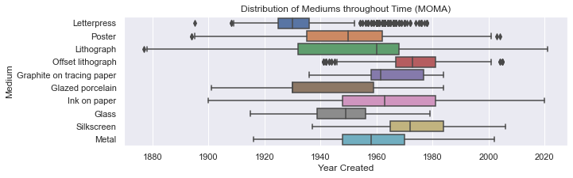

```python
#boxplot for moma
sns.set(font_scale = 1.4)
sns.set(rc = {'figure.figsize': (10,3)})
moma_med_boxplots = sns.boxplot(data = moma_no_outliers, x = 'Date', y = 'Medium')
moma_med_boxplots.set(xlabel = 'Year Created', ylabel = 'Medium')
moma_med_boxplots.set(title = 'Distribution of Mediums throughout Time (MOMA)')
```

```
Letterpress: (1934, 1935)
Poster: (1943, 1949)
Lithograph: (1952, 1953)
Offset lithograph: (1973, 1975)
Graphite on tracing paper: (1958, 1968)
Glazed porcelain: (1937, 1947)
Ink on paper: (1963, 1965)
Glass: (1946, 1950)
Silkscreen: (1974, 1977)
Metal: (1942, 1974)
```

```
[Text(0.5, 1.0, 'Confidence Interval of Expected Years (MOMA)')]
```

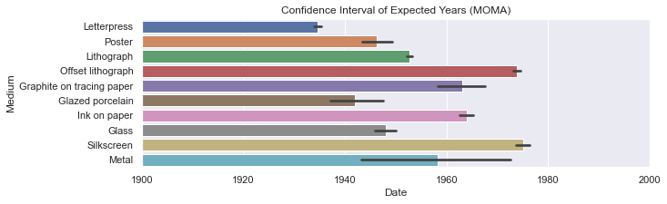

```python
#moma confidence interval
date = "Date"
for i in range(len(moma_unknown_med)):
    selected_med = moma_unknown_med[i]
    selected_df = moma_no_outliers.loc[moma_no_outliers['Medium']==selected_med]
    standard_dev(selected_df, selected_med, date)

#confidence interval MOMA
ax = sns.barplot(x='Date', y = 'Medium', data=moma_no_outliers)
ax.figure.set_figwidth(10)
ax.set_xlim(1900,2000)
ax.set(title = 'Confidence Interval of Expected Years (MOMA)')
```

```
[Text(0.5, 1.0, 'Distribution of Mediums throughout Time (TATE)')]
```

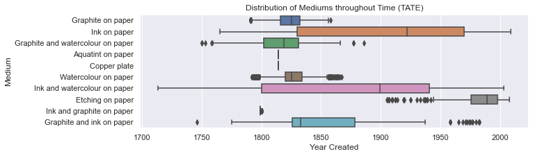

```python
#boxplot for tate
sns.set(font_scale = 1.4)
sns.set(rc = {'figure.figsize': (10,3)})
tate_med_boxplots = sns.boxplot(data = tate_no_outliers, x = 'year', y = 'medium')
tate_med_boxplots.set(xlabel = 'Year Created', ylabel = 'Medium')
tate_med_boxplots.set(title = 'Distribution of Mediums throughout Time (TATE)')
```

```
Graphite on paper: (1823, 1823)
Ink on paper: (1899, 1913)
Graphite and watercolour on paper: (1817, 1819)
Aquatint on paper: (1814, 1814)
Copper plate: (1814, 1814)
Watercolour on paper: (1825, 1827)
Ink and watercolour on paper: (1864, 1888)
Etching on paper: (1985, 1986)
Ink and graphite on paper: (1799, 1799)
Graphite and ink on paper: (1842, 1867)
```

```
[Text(0.5, 1.0, 'Confidence Interval of Expected Years (TATE)')]
```

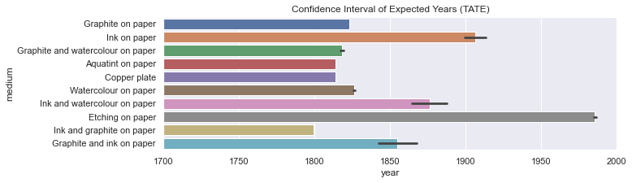

```python
#tate confidence interval
date = 'year'
for i in range(len(tate_unknown_med)):
    selected_med = tate_unknown_med[i]
    selected_df = tate_no_outliers.loc[tate_no_outliers['medium']==selected_med]
    standard_dev(selected_df, selected_med, date)

#confidence interval tate
ax = sns.barplot(x='year', y = 'medium', data=tate_no_outliers)
ax.figure.set_figwidth(10)
ax.set_xlim(1700,2000)
ax.set(title = 'Confidence Interval of Expected Years (TATE)')
```

### 6.2 Analysis 2

*By Riley Otsuki*

In order to answer the second question and find the distribution of different mediums/dimensions of the artwork. One of the primary issues when analyzing the mediums/dimensions of the artworks was that the Block dataset did not catalog mediums or the dimensions. Although the dataset had a “classification” category for the artworks, it was too vague to associate a piece of art with certain mediums. As a result, for the purpose of this analysis only the MoMA and Tate works were used. This can be justified by the fact that the MoMA and the Tate Museum are much larger museums attended by visitors from around the world and seemingly “present” an equal representation of art.

Before looking at the distribution of mediums/dimensions over time, the popularity of the mediums were first analyzed by using value_counts() and using a barplot to visualize the results. Because there were a plethora of mediums, for the purpose of visualization the top 10 mediums were plotted. To understand these top 10 mediums even more, they were divided by the amount of artworks to get a percentage.

```python
import pandas as pd
import matplotlib.pyplot as plt
import seaborn as sns
import numpy as np

block_works = pd.read_csv('Downloads/block_works_cleaned.csv')
moma_works = pd.read_csv('Downloads/moma_works_cleaned.csv')
tate_works = pd.read_csv('Downloads/tate_works_cleaned.csv')
```

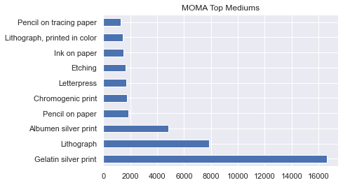

```python
#turns all years into numerics
moma_works['Date'] = pd.to_numeric(moma_works['Date'], errors='coerce')
tate_works['year'] = tate_works['year'].astype(int, errors='ignore')

#for MoMA value_counts()
moma_works['Medium'].value_counts().head(10)

#for MoMA value_counts() as a percentage
moma_works['Medium'].value_counts().head(10)/moma_works.shape[0]

#for MoMA top 10 mediums plot
moma_works['Medium'].value_counts()[:10].plot(kind='barh', figsize=(6,4), title='MOMA Top Mediums')
```

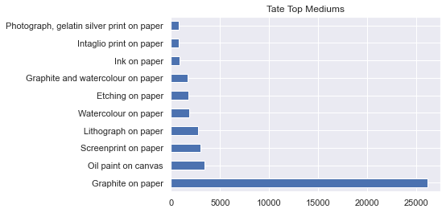

```python
#for Tate value_counts()
tate_works['medium'].value_counts().head(10)

#for Tate value_counts() as a percentage
tate_works['medium'].value_counts().head(10)/tate_works.shape[0]

#for Tate top 10 mediums plot
tate_works['medium'].value_counts()[:10].plot(kind='barh', figsize=(6,4), title='Tate Top Mediums')
```

To visualize the mediums’ popularity over time, we used displot() from seaborn to create a histogram. The hue was set to the medium of the works in order to see the trend of certain mediums over time. In order to avoid confusion and clutter, the top 5 mediums were used. Furthermore, the x axis was narrowed down to the range in which the museum had works.

```
(1800.0, 2020.0)
```

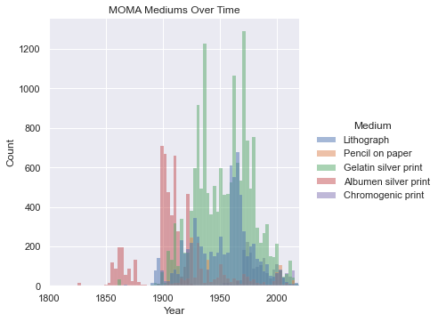

```python
#for MoMA medium visualization over time
filtered_medium = moma_works['Medium'].value_counts()[0:5].index.to_list()
filtered_moma_df = moma_works[moma_works['Medium'].isin(filtered_medium)]
sns.set (font_scale = 1)
a = sns.displot(data = filtered_moma_df, x ='Date',kind = 'hist', hue='Medium')
plt.title("MOMA Mediums Over Time")
a.set_axis_labels ("Year", "Count")
plt.xlim([1800, 2020])
```

```
(1700.0, 2020.0)
```

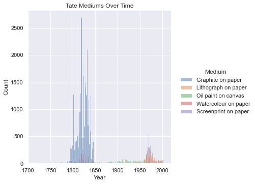

```python
#for Tate medium visualization over time
tate_works['Medium'] = tate_works['medium']
filtered_medium_tate = tate_works['Medium'].value_counts()[0:5].index.to_list()
filtered_tate_df = tate_works[tate_works['Medium'].isin(filtered_medium_tate)]
sns.set (font_scale = 1)
a = sns.displot(data = filtered_tate_df, x ='year', kind='hist', hue='Medium')
plt.title('Tate Mediums Over Time')
a.set_axis_labels ("Year", "Count")
plt.xlim([1700, 2020])
```

In order to analyze the dimensions of the MoMA and Tate works we first created a new column named ‘Square Cm’ for MoMA and ‘Square Mm’ for Tate in accordance with the units that each data set was in. The width and the height columns were then multiplied to create such new columns. This would allow each artwork to be represented by a single number and make it easier to visualize the changes in dimensions over time. However, plotting every observation would make it difficult to analyze any trends given the sheer amount of artworks, the artworks were grouped by year using groupby() and the mean dimension of each year was plotted against time.

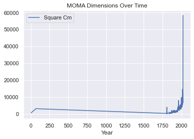

```python
#for MoMA dimensions over time
moma_works['Square Cm'] = moma_works['Height (cm)'] * moma_works['Width (cm)']
moma_dimensions = moma_works.groupby(['Date']).mean().plot(kind='line', figsize=(6, 4), y='Square Cm', title='MOMA Dimensions Over Time')
moma_dimensions.set_xlabel('Year')
```

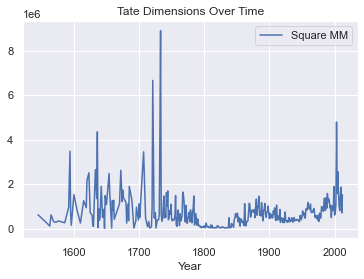

```python
#for Tate dimensions over time
tate_works['width'] = pd.to_numeric(tate_works['width'], errors='coerce')
tate_works['height'] = pd.to_numeric(tate_works['height'], errors='coerce')
tate_works['Square MM'] = tate_works['width'] * tate_works['height']
tate_dimensions = tate_works.groupby(['year']).mean().plot(kind='line', figsize=(6, 4), y='Square MM',
                                                           title='Tate Dimensions Over Time')
tate_dimensions.set_xlabel('Year')
```

**Observations:**

Mediums - The top 3 mediums for MoMA were “Gelatin silver print”, “Lithograph”, and “Albumen Silver Print” The top 3 mediums for Tate were “Graphite on paper”, “Oil paint on canvas”, and “Screenprint on paper”

Mediums over time - No medium seems to have a consistent amount of artwork every year, suggesting that mediums like “fads” seem to be popular for only a certain amount of time.

Dimensions - MoMA and Tate show similar trends after 1800, where the dimensions of the art seem to have increased in recent years. The high variability in dimensions for Tate prior to the 1800s may be attributed to less traditional artworks such as statues that are less seen in recent years.

### 6.3 Analysis 3

*By Lila Weiner*

As previously mentioned, the first step in exploring artwork age was to prepare the columns which signified creation date. To account for common cases of creation dates, we subsetted these inputs using a series of filtering processes. After addressing these cases, we converted the year column to numeric in order to analyze the variable. To create a new “artwork age” column, we subtracted the creation date from 2022. We also added a column to each dataset, which specified the museum. This column proved to be useful after we concatenated the artwork ages of all of the museums.

```python
import pandas as pd
import numpy as np
import matplotlib.pyplot as plt
import sklearn as sk
import seaborn as sb

#Creating the artwork age variable.
block_list = ["Block" for x in range(block_works_cleaned.shape[0])]
block_works_cleaned['Artwork_Age'] = 2022 - block_works_cleaned['Date']
block_works_cleaned['Museum'] = block_list

#Creating the artwork age variable.
moma_list = ["Moma" for x in range(moma_works_cleaned.shape[0])]
moma_works_cleaned['Artwork_Age'] = 2022 - moma_works_cleaned['Date']
moma_works_cleaned['Museum'] = moma_list

#Creating the artwork age variable.
tate_list = ["Tate" for x in range(tate_works_cleaned.shape[0])]
tate_works_cleaned['Artwork_Age'] = 2022 - tate_works_cleaned['year']
tate_works_cleaned['Museum'] = tate_list
```

Once we added the new columns, we computed the summary statistics of artwork age. Initially, we subsetted the three datasets for the new “museum name” and “artwork age” columns, and then vertically concatenated these subsetted datasets. From here, we grouped the concatenated dataset by “museum name”, and computed the mean, median, and standard deviation of artwork age using .agg(). The standard deviation of the Block museum is higher than the other two museums, which indicates the larger variation of the museum’s collection. The Block museum’s variation is notable, as it proves that a small scale museum has a relative ability to collect old and new artworks alike.

```python
#subsetting the datasets
moma_ages = moma_works_cleaned.loc[:, ['Artwork_Age', 'Museum']]
block_ages = block_works_cleaned.loc[:, ['Artwork_Age', 'Museum']]
tate_ages = tate_works_cleaned.loc[:, ['Artwork_Age', 'Museum']]

#concatenation
block_and_moma_and_tate = pd.concat([block_ages, tate_ages, moma_ages],keys = ['Block','Tate', 'Moma'])

#grouping and summary statistics
grouped = block_and_moma_and_tate.groupby('Museum')
grouped['Artwork_Age'].std().sort_values(ascending = False)
grouped['Artwork_Age'].mean().sort_values(ascending = False)
grouped['Artwork_Age'].median().sort_values(ascending = False)
```

```
Museum
Tate     191.0
Moma      59.0
Block     53.0
Name: Artwork_Age, dtype: float64
```

With the concatenated dataset, we then visualized the artwork ages of the three museums with a stacked histogram. Using displot() from the seaborn library, we plotted the artwork ages with the specification “hue = museum”. On this histogram, we added three vertical lines that denoted the mean artwork age of each artwork museum.

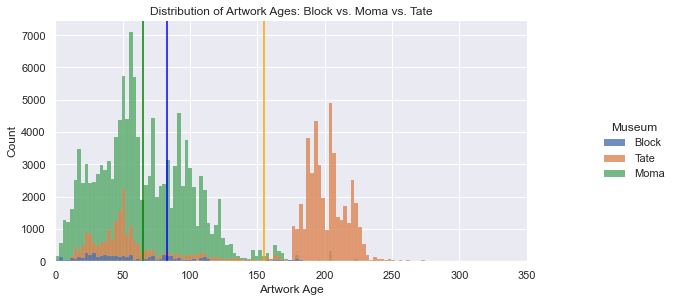

```python
sb.set(font_scale = 1)
a = sb.displot(data = block_and_moma_and_tate, x = 'Artwork_Age',kind = 'hist', hue='Museum', alpha=.8).set(title='Distribution of Artwork Ages: Block vs. Moma vs. Tate')
a.set_axis_labels("Artwork Age", "Count")
a.set(xlim=(0,350))

a.figure.set_figwidth(10)
a.figure.set_figheight(4)

plt.axvline(block_works_cleaned['Artwork_Age'].mean(), 0,400, color='blue') #the block age
plt.axvline(moma_works_cleaned['Artwork_Age'].mean(), 0,400, color='green') #the moma age
plt.axvline(tate_works_cleaned['Artwork_Age'].mean(), 0,400, color='orange') #the tate age
```

The artwork age distribution of Tate’s collection is significantly older than the Moma and Block museums. While the Tate distribution is centered around 150 years, most of the Moma and Block artworks are under 100 years old. Generally, the distribution trends align with the mean age of the three museums, as the mean age for Tate is approximately 72 years older than the Block, and 90 years older than the Moma. Tate’s older artwork collection could be attributed to the museum age. The Tate Museum was founded in 1897, and is the oldest of the three museums. Tate museum is also located in England, and is in closer geographic proximity to artworks that were produced in Eastern centered art movements. Also, the continued act of preserving older artworks is costly: the physical elements of an aged artwork require meticulous upkeep, temperature regulation and protection. Hence, the Tate museum is opportunely situated in regard to location and time, and might also have more resources to collect older artworks. Following the stacked histogram of artwork age, we decided to compare artwork age and acquisition year. The acquisition date column is only present in the Moma and Tate datasets, so the Block data was not used in this regard. For the two datasets, we made a new column “acquisition age” that is the acquisition year subtracted by the creation year. Acquisition date was initially represented by a year-month-day string in both dataframes, so we subsetted for the four digit year in order to complete the subtraction. Finally, we plotted the “acquisition age” using displot() to visualize the distribution.

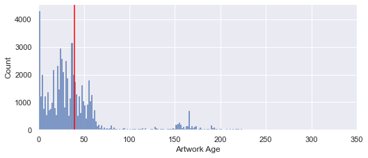

```python
#Tate Museum: date acquired preparation:
list_date_acquired = tate_works_cleaned['acquisitionYear'].to_list()

for i in range(63805):
    if type(list_date_acquired[i])==float:
        list_date_acquired[i] = str(list_date_acquired[i])

for x in range(63805):
    list_date_acquired[x] = list_date_acquired[x][0:4]

tate_works_cleaned['acquisitionYear'] = list_date_acquired

good_ones = []
for i in range(63805):
    if (len(tate_works_cleaned['acquisitionYear'][i])==4) & (tate_works_cleaned['acquisitionYear'][i][0]!='n'):
        good_ones.append(i)

tate_works_cleaned = tate_works_cleaned.iloc[good_ones,:].reset_index()
tate_works_cleaned['acquisitionYear'] = pd.to_numeric(tate_works_cleaned['acquisitionYear'])

#Creating the "age at acquisition" variable
tate_works_cleaned['Age_at_acquisition'] = tate_works_cleaned['acquisitionYear']-tate_works_cleaned['year']

sb.set(font_scale = 1)
a = sb.displot(data = tate_works_cleaned, x = 'Age_at_acquisition',kind = 'hist')
a.set_axis_labels("Artwork Age", "Count")
a.set(xlim=(0,350))
plt.axvline(tate_works_cleaned['Age_at_acquisition'].mean(), 0,400, color='red') #the tate age

a.figure.set_figwidth(8)
a.figure.set_figheight(3)
```

```
0.30686998002201654
```

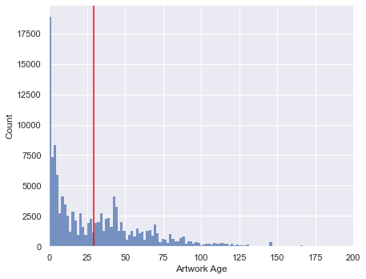

```python
#Acquisition date preparation
list_date_acquired = moma_works_cleaned['DateAcquired'].to_list()
list_date_acquired

for i in range(128624):
    if type(list_date_acquired[i])==float:
        list_date_acquired[i] = str(list_date_acquired[i])
list_date_acquired

for x in range(128624):
    list_date_acquired[x] = list_date_acquired[x][0:4]
list_date_acquired

moma_works_cleaned['DateAcquired'] = list_date_acquired

good_ones = []
for i in range(128624):
    if len(moma_works_cleaned['DateAcquired'][i])==4:
        good_ones.append(i)

moma_works_cleaned = moma_works_cleaned.iloc[good_ones,:].reset_index()
moma_works_cleaned['DateAcquired'] = pd.to_numeric(moma_works_cleaned['DateAcquired'])
moma_works_cleaned['Age_at_acquisition'] = moma_works_cleaned['DateAcquired']-moma_works_cleaned['Date']

sb.set(font_scale = 1)
a = sb.displot(data = moma_works_cleaned, x = 'Age_at_acquisition',kind = 'hist')
a.set_axis_labels("Artwork Age", "Count")
a.set(xlim=(0,200))
plt.axvline(moma_works_cleaned['Age_at_acquisition'].mean(), 0,400, color='red') #the tate age

a.figure.set_figwidth(8)
ax.figure.set_figheight(3)
moma_works_cleaned['Age_at_acquisition'].mean()
moma_works_cleaned['Age_at_acquisition'].value_counts()[0:6].sum()/len(moma_works_cleaned['Age_at_acquisition'])
```

### 6.4 Analysis 4

*By Gabrielle Bliss*

The demographic analysis of artists represented in the MoMA, Tate, and Block museums utilized the museum artist databases the most, and aims to depict the representation of artists by nationality and gender in order to inform future acquisitions. As aforementioned in the background of our project, a general consensus among museums today is that their collections should avoid overlooking historically marginalized groups, and by performing an analysis of nationality and gender of represented artists in these three museums, acquisitionists and other stakeholders will be informed on how to better make ethical acquisitions.

Using the clean data in the gender columns of the Tate and MoMA datasets, I was able to create a visualization of gender distribution for both of these museums using a stacked barplot. This stacked barplot visualized the distribution between “Male” and “Female” genders for both museums, while also displaying the proportion of artists that identify as “Non-Binary” in the MoMA’s collection. In order to achieve this particular visualization, the crosstab() function had to be used on both of the gender columns for both museums, with a normalizing argument in order to visualize proportions. A distribution visualization with regards to proportion of genders in represented artists was ideal since the sample size of genders for artists in both museums differed.

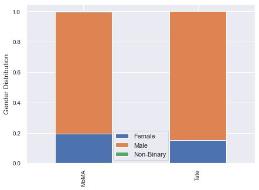

```python
gender_proportion_tatemuseum = pd.crosstab(index='Tate', columns=tate_artists['gender'], normalize='index')
gender_proportion_moma = pd.crosstab(index='MoMA', columns=moma_artists['Gender0'], normalize='index')
gender_proportion = pd.concat([gender_proportion_moma, gender_proportion_tatemuseum], axis = 0)
gender_proportion.loc['Tate', 'Non-Binary'] = 0

ax = gender_proportion.plot.bar(stacked=True,ylabel = 'Gender Distribution',figsize=(15, 10), xlabel = '')
ax.tick_params(axis = 'both',labelsize=10)
ax.figure.set_figwidth(7)
ax.figure.set_figheight(5)
```

Once the stacked barplot was visualized, one can observe that the artists represented in the Tate museum’s artwork collection are highly dominated by male-identifying artists; specifically, the visualization suggests that greater than 80% of Tate artists with gender specified in the dataset are male-identifying. Less than 20% are female-identifying. The represented artists in MoMA’s collection has a higher proportion of female-identifying artists, though not by much. This distribution is about 80:20 male to female-identifying artists, with a sliver of the gender proportions representing the non-binary artists. The small proportion of non-binary artists represented in the MoMA data might be reflective of the smaller proportion of this gender identity in the overall population of artists internationally, but analyzing this data through the lens of ethical representation and acquisition suggests that this should be an area of focus for museums to improve representation of artists in their collections.

It is important to note that the visualization calculates proportion without taking missing values into account. When calculating percentages/proportions of gender represented in the entire dataset (including missing values), the proportions are slightly different, as they are being divided by all entries, including the missing values. In the Tate dataset, very specifically 3.3% of the represented artists have a missing gender when cataloged, 14.8% of the represented artists are female-identifying, and 82.0% are male-identifying. There are 2895 male-identifying artists listed, and 521 female-identifying.

```python
print('The percentage of null values in artist gender for Tate is',tate_artists.isnull().sum().gender/tate_artists.shape[0]*100, '%')
print('The percentage of female-identifying artists represented in the Tate collection is',(tate_artists.gender.value_counts()['Female']/tate_artists.shape[0])*100, '%')
print('The percentage of male-identifying artists represented in the Tate collection is', (tate_artists.gender.value_counts()['Male']/tate_artists.shape[0])*100, '%\n')

print('The percentage of null values in artist gender for the MoMA is', moma_artists.Gender.isnull().sum()/moma_artists.shape[0]*100, '%')
print('The percentage of non-binary artists represented in the MoMA collection is', (moma_artists.Gender0.value_counts()['Non-Binary']/moma_artists.shape[0])*100, '%')
print('The percentage of female-identifying artists represented in the MoMA collection is', (moma_artists.Gender0.value_counts()['Female']/moma_artists.shape[0])*100, '%')
print('The percentage of male-identifying artists represented in the MoMA collection is', (moma_artists.Gender0.value_counts()['Male']/moma_artists.shape[0])*100, '%')
```

```
The percentage of null values in artist gender for Tate is 3.2842582106455263 %
The percentage of female-identifying artists represented in the Tate collection is 14.750849377123442 %
The percentage of male-identifying artists represented in the Tate collection is 81.96489241223102 %

The percentage of null values in artist gender for the MoMA is 20.763629206849046 %
The percentage of non-binary artists represented in the MoMA collection is 0.0196811651249754 %
The percentage of female-identifying artists represented in the MoMA collection is 15.370989962605785 %
The percentage of male-identifying artists represented in the MoMA collection is 63.8456996654202 %
```

For the MoMA, 20.8% of the represented artists have a missing gender when cataloged, 0.02% of the represented artists are non-binary, 15.4% of represented artists are female-identifying, and 63.8% of artists are male-identifying. Since there is a larger percentage of missing values for gender in the MoMA artists dataset (which cannot be imputed reasonably and/or ethically since gender is self-identified), doing a cross analysis of these missing values with our other variable of interest, nationality, lends insight into the variables we are losing in a different context. The top 5 nationalities for artists without a specified gender are American, German, British, French, and Italian, which sheds light on the results of the next part of analysis, which is focused around nationality.

```python
missing_moma_gender = moma_artists[moma_artists.Gender.isnull()]
index_null_gender_moma = missing_moma_gender.index.to_list()
print(moma_artists.loc[index_null_gender_moma, :].Nationality.value_counts()[0:6])
moma_artists.loc[index_null_gender_moma, :].head()
```

```
American               471
German                 101
British                 94
French                  85
Italian                 73
Nationality unknown     65
Name: Nationality, dtype: int64
```

|  | Unnamed: 0 | ConstituentID | DisplayName | ArtistBio | Nationality | Gender | BeginDate | EndDate | Wiki QID | ULAN | Gender0 |
| --- | --- | --- | --- | --- | --- | --- | --- | --- | --- | --- | --- |
| 14 | 14 | 18 | Artko | NaN | NaN | NaN | 0 | 0 | NaN | NaN | NaN |
| 21 | 21 | 26 | Göran Åslin | Swedish, born 1940 | Swedish | NaN | 1940 | 0 | NaN | NaN | NaN |
| 26 | 26 | 32 | Atelier Eggers | French | French | NaN | 0 | 0 | NaN | NaN | NaN |
| 27 | 27 | 33 | A.A.P. | American | American | NaN | 0 | 0 | NaN | NaN | NaN |
| 68 | 68 | 78 | Aftograf | Russian | Russian | NaN | 0 | 0 | NaN | NaN | NaN |

After cleaning the datasets for nationality as described in the previous data cleaning and preparation section, pie charts were created to visualize the distribution of nationalities for the artists represented at all three museums. In order to display the percentages with a cutoff of 1% displayed, I defined a function that removed percentages based on a defined limit, which for all the pie charts I set to 1%.

The pie chart created for the MoMA displays that 41% of the artists have an American nationality. The next four nationalities in terms of highest percentage are European nationalities, and the first Asian nationality represented is Japanese, which is 4% of artist nationalities represented in the MoMA’s collection.

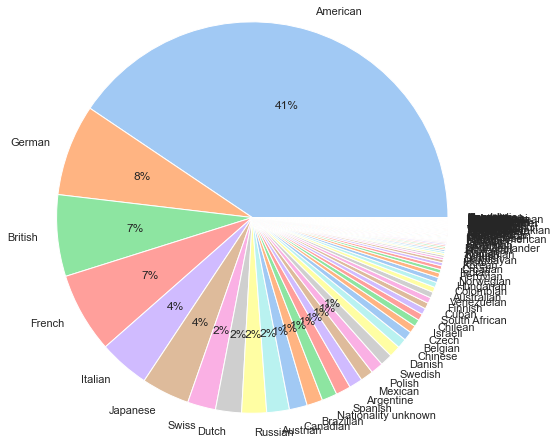

```python
import matplotlib.pyplot as plt
import seaborn as sns

def pct_remove(limit):
    """Remove percent on small slices."""
    def inner_pct(pct):
        return ('%.0f%%' % pct) if pct > limit else ''
    return inner_pct

#defining Seaborn color palette to use
colors = sns.color_palette('pastel')[0:len(moma_artists.Nationality.value_counts())]

data = moma_artists.Nationality.value_counts(normalize=True)

#create pie chart
momapie = plt.pie(x=data, labels = data.index, colors = colors, autopct=pct_remove(1), radius=3)
```

The pie chart created for the Tate displays that 49% of the artists have a British nationality, which has been defined as being born in the UK. Artists with an American nationality make up 11% of the artist population at the Tate. The next four nationalities in terms of highest percentage are European nationalities, and no non-European nationalities are represented above the 1% threshold.

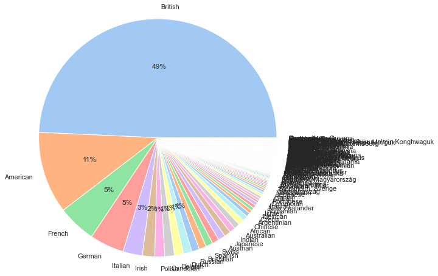

```python
#defining Seaborn color palette to use
colors = sns.color_palette('pastel')[0:len(tate_artists.Nationality.value_counts())]

data = tate_artists.Nationality.value_counts(normalize=True)

#create pie chart
tatepie = plt.pie(x=data, labels = data.index, colors = colors, autopct=pct_remove(1), radius=3)
```

Finally, the pie chart created for the Block displays that 64% of the artists have an American nationality. Artists of distinct European nationalities make up the next four nationalities in terms of highest percentage, followed by a 2% value of artists with unknown nationality. The first Asian nationality is represented at 1% of all artists represented within the Block’s collection, and this nationality is Japanese.

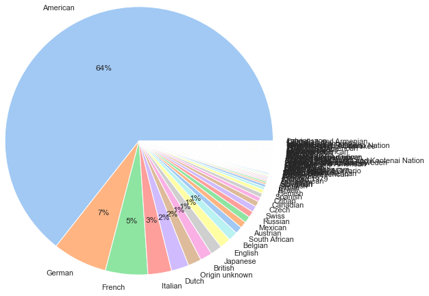

```python
#defining Seaborn color palette to use
colors = sns.color_palette('pastel')[0:len(tate_artists.Nationality.value_counts())]

data = df_onlynat.value_counts(normalize=True)

#create pie chart
bloxkpie = plt.pie(x=data, labels = data.index, colors = colors, autopct=pct_remove(1), radius=3)
```

## 8 Recommendations to stakeholders

In our first analysis, our stakeholders are presented with a 95% confidence interval that estimates when an artwork was created. The confidence intervals present art curators the chance to realize further trends of artworks throughout time. With this information, curators can better understand the artwork and its role in the historical context of when it was created, and refer to these estimated intervals when looking for an artwork from a specific time period to acquire. Also, art curators can present visitors with more accurate information about the artwork dates through our confidence intervals, which presents a deeper comprehension of trends of acquired artworks.

The second analysis depicts the most pervasive mediums featured in the museums which to stakeholders, specifically museum curators, signals that there needs to be more diversity in terms of the mediums of the work. A potential solution to this would be to introduce artworks with mediums that originated from underrepresented countries as opposed to popular mediums that feature mainly European artists. Further, looking at the dimensions, there seems to be an upward trend in the size of artworks since the 1800s. For art researchers there is an interesting trend in terms of art dimensions in relation to time.

While all three museums contain both old and new artworks, there are measures that can be taken in order to ensure that smaller scale museums can present historical works of art to their audiences. We suggest that larger museums, such as the Tate museum, loan older artworks to small scale museums for temporary exhibitions. Temporary exhibitions succeed in spreading artwork of differing ages to new audiences, and promoting the museum that is lending the art. There are financial costs of temporary exhibitions, since they require considerable effort to transport artworks carefully. However, two museums in close proximity could organize a temporary exhibition without shipping artworks across states/countries. For instance, the Art Institute of Chicago and the Block Museum might consider collaborating in order to bring works from the Art Institute to Northwestern’s campus. There are also organizations in place to guide the creation of temporary exhibitions, such as the Touring Exhibitions Group, based in the United Kingdom.

The analysis of artist demographics primarily provides the most pertinent, specific recommendations to museum acquisition teams and collectors, as opposed to the other stakeholders that our project could be applicable to. When making acquisitions, in order to further diversify the artists represented in the various museums’ collections, acquisition teams can look to these distributions to inform where they are lacking in terms of representation. For example, all analyzed museums could increase their representation of artists with Asian nationalities. The Tate and MoMA should focus acquisitions on works done by artists that are female-identifying or of another gender than male when looking to diversify their collections in terms of these variables.

## References

[1] “Home: Ethical Cataloging.” PMA LibGuides, https://philamuseum.libguides.com/home/about-us/ethical-cataloging.

[2] MuseumofModernArt. “The Museum of Modern Art (MoMA) Collection Data.” GitHub, https://github.com/MuseumofModernArt/collection#:~:text=7%20years%20ago-,Artists.csv,-Automatic%20monthly%20update

**The links to access these public data sources are:**

MoMA: https://github.com/MuseumofModernArt/collection#:~:text=7%20years%20ago-,Artists.csv,-Automatic%20monthly%20update https://github.com/MuseumofModernArt/collection#:~:text=20%20days%20ago-,Artworks.csv,-Automatic%20monthly%20update

Tate: https://github.com/tategallery/collection#:~:text=2%20years%20ago-,artist_data.csv,-Oct%2014%20metadata https://github.com/tategallery/collection#:~:text=8%20years%20ago-,artwork_data.csv,-Oct%2014%20metadata

**The links to the tables used to create datasets for the Block collection are:**

https://blockmuseum.emuseum.com/people https://blockmuseum.emuseum.com/objects/table?page=1

## Appendix

```python
import pandas as pd
b1 = pd.read_csv('Downloads/block_artists.csv')
b2 = pd.read_csv('Desktop/STAT3031/block_works.csv')
m1 = pd.read_csv('Downloads/moma_artists.csv')
t1 = pd.read_csv('Downloads/tate_artists.csv')
m2 = pd.read_csv('Desktop/STAT3031/moma_works.csv')
t2 = pd.read_csv('Desktop/STAT3031/tate_works.csv')
```

```python
# Missing values in block_artists column pertinent to nationality
b1.Date.isnull().sum()
```

```
260
```

```python
# Unique values in block_artists column pertinent to nationality
b1.Date.nunique()
```

```
984
```

```python
# Value counts in block_artists column pertinent to nationality
b1.Date.value_counts()[0:5]
```

```
American               76
American, born 1943    23
Origin unknown         21
American, born 1947    18
American, born 1948    18
Name: Date, dtype: int64
```

```python
# Value counts in block column after cleaned for nationality
b1['Nationality'] = b1.Date.str.split(',')
natnull = b1[b1.Nationality.isnull()].index.to_list()
natyes = b1.Nationality.dropna().index.to_list()
df_nat = pd.DataFrame(b1.loc[natyes, :].Nationality.tolist()).fillna('').add_prefix('nat')
df_nat.nat0.value_counts()
```

```
American                 970
German                    99
French                    77
Italian                   43
Dutch                     32
                        ...
Ho-Chunk/Pechanga          1
Danish                     1
1720 - 1790                1
Canadian and Armenian      1
Latvian                    1
Name: nat0, Length: 91, dtype: int64
```

```python
# Missing values in moma nationality column
m1.Nationality.isnull().sum()
```

```
2472
```

```python
# Unique values in moma nationality column
m1.Nationality.nunique()
```

```
119
```

```python
# Value counts of moma nationality column
m1.Nationality.value_counts()[0:5]
```

```
American    5181
German       965
British      860
French       847
Italian      536
Name: Nationality, dtype: int64
```

```python
# Missing values in moma gender column
m1.Gender.isnull().sum()
```

```
3165
```

```python
# Unique values in moma gender column
m1.Gender.nunique()
```

```
6
```

```python
# Value counts of moma gender column
m1.Gender.value_counts()
```

```
Male          9715
Female        2342
male            17
Non-Binary       2
female           1
Non-binary       1
Name: Gender, dtype: int64
```

```python
# Missing values in tate artists column pertinent to nationality
t1.placeOfBirth.isnull().sum()
```

```
492
```

```python
# Unique values in tate artists column pertinent to nationality
t1.placeOfBirth.nunique()
```

```
1263
```

```python
# value counts in tate artists column pertinent to nationality
t1.placeOfBirth.value_counts()[0:5]
```

```
London, United Kingdom       446
Paris, France                 57
Edinburgh, United Kingdom     47
New York, United States       43
Glasgow, United Kingdom       35
Name: placeOfBirth, dtype: int64
```

```python
# Missing values in tate artists column pertinent to gender
t1.gender.isnull().sum()
```

```
116
```

```python
# Unique values in tate artists column pertinent to gender
t1.gender.nunique()
```

```
2
```

```python
# value counts in tate artists column pertinent to gender
t1.gender.value_counts()
```

```
Male      2895
Female     521
Name: gender, dtype: int64
```